# COMPSCIX 415.2 Homework 5/Midterm

## The tidyverse packages (3 points)

By now you’ve used at least five different packages from the tidyverse for plotting, data munging, reshaping data, importing/exporting data, and using tibbles (the tibble package is used for this without you even realizing it’s there).

### Can you name which package is associated with each task below?

Plotting - ggplot2 Data munging/wrangling - dplyr Reshaping (speading and gathering) data - tidyr Importing/exporting data - readr

## R Basics (1.5 points)

1)Fix this code with the fewest number of changes possible so it works: My_data.name___is.too00ooLong! <- c( 1 , 2 , 3 )

```r
My_data_name___is_too00ooLong <- c( 1 , 2   , 3 )
My_data_name___is_too00ooLong
```

```
## [1] 1 2 3
```

2)Fix this code so it works: my_string <- C(‘has’, ‘an’, ‘error’, ‘in’, ’it)

```r
my_string <- c('has','an','error','in','it')
my_string
```

```
## [1] "has"   "an"    "error" "in"    "it"
```

3)Look at the code below and comment on what happened to the values in the vector. my_vector <- c(1, 2, ‘3’, ‘4’, 5) my_vector

```r
my_vector <- c(1, 2, '3', '4', 5)
my_vector
```

```
## [1] "1" "2" "3" "4" "5"
```

THe values in the vector were converted to strings.

## Data import/export (3 points)

Download the rail_trail.txt file from Canvas (in the Midterm Exam section) and successfully import it into R. Prove that it was imported successfully by including your import code and taking a glimpse of the result.

Export the file into a comma-separated file and name it “rail_trail.csv”. Make sure you define the path correctly so that you know where it gets saved. Then reload the file. Include your export and import code and take another glimpse.

```r
library(tidyverse)
heights <- read_csv("/Users/dianacuesta/Compscisx-415-2/rail_trail.csv")
glimpse(heights)
```

```
## Observations: 90
## Variables: 10
## $ hightemp   <int> 83, 73, 74, 95, 44, 69, 66, 66, 80, 79, 78, 65, 41,...
## $ lowtemp    <int> 50, 49, 52, 61, 52, 54, 39, 38, 55, 45, 55, 48, 49,...
## $ avgtemp    <dbl> 66.5, 61.0, 63.0, 78.0, 48.0, 61.5, 52.5, 52.0, 67....
## $ spring     <int> 0, 0, 1, 0, 1, 1, 1, 1, 0, 0, 0, 1, 1, 0, 0, 1, 0, ...
## $ summer     <int> 1, 1, 0, 1, 0, 0, 0, 0, 1, 1, 1, 0, 0, 0, 0, 0, 1, ...
## $ fall       <int> 0, 0, 0, 0, 0, 0, 0, 0, 0, 0, 0, 0, 0, 1, 1, 0, 0, ...
## $ cloudcover <dbl> 7.6, 6.3, 7.5, 2.6, 10.0, 6.6, 2.4, 0.0, 3.8, 4.1, ...
## $ precip     <dbl> 0.00, 0.29, 0.32, 0.00, 0.14, 0.02, 0.00, 0.00, 0.0...
## $ volume     <int> 501, 419, 397, 385, 200, 375, 417, 629, 533, 547, 4...
## $ weekday    <int> 1, 1, 1, 0, 1, 1, 1, 0, 0, 1, 1, 1, 1, 1, 1, 1, 0, ...
```

```r
write_csv(heights, "/Users/dianacuesta/Compscisx-415-2/rail_trails.csv")
heights <- read_csv("/Users/dianacuesta/Compscisx-415-2/rail_trails.csv")
glimpse(heights)
```

```
## Observations: 90
## Variables: 10
## $ hightemp   <int> 83, 73, 74, 95, 44, 69, 66, 66, 80, 79, 78, 65, 41,...
## $ lowtemp    <int> 50, 49, 52, 61, 52, 54, 39, 38, 55, 45, 55, 48, 49,...
## $ avgtemp    <dbl> 66.5, 61.0, 63.0, 78.0, 48.0, 61.5, 52.5, 52.0, 67....
## $ spring     <int> 0, 0, 1, 0, 1, 1, 1, 1, 0, 0, 0, 1, 1, 0, 0, 1, 0, ...
## $ summer     <int> 1, 1, 0, 1, 0, 0, 0, 0, 1, 1, 1, 0, 0, 0, 0, 0, 1, ...
## $ fall       <int> 0, 0, 0, 0, 0, 0, 0, 0, 0, 0, 0, 0, 0, 1, 1, 0, 0, ...
## $ cloudcover <dbl> 7.6, 6.3, 7.5, 2.6, 10.0, 6.6, 2.4, 0.0, 3.8, 4.1, ...
## $ precip     <dbl> 0.00, 0.29, 0.32, 0.00, 0.14, 0.02, 0.00, 0.00, 0.0...
## $ volume     <int> 501, 419, 397, 385, 200, 375, 417, 629, 533, 547, 4...
## $ weekday    <int> 1, 1, 1, 0, 1, 1, 1, 0, 0, 1, 1, 1, 1, 1, 1, 1, 0, ...
```

### Visualization (6 points)

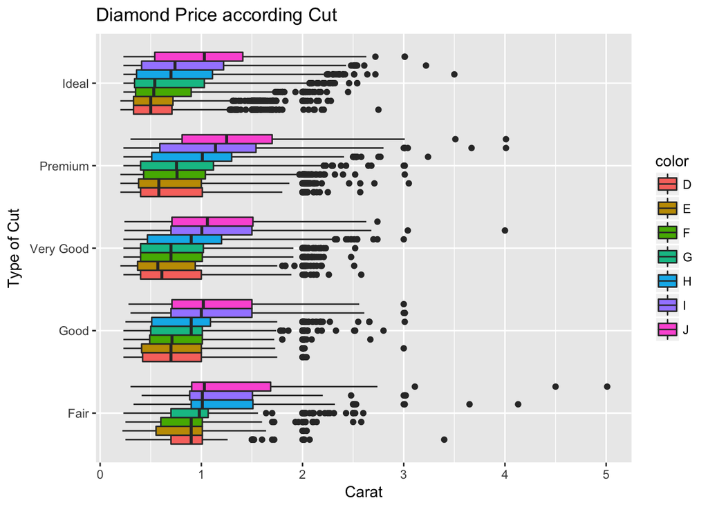

```r
library(ggplot2)
data(diamonds)
ggplot(diamonds, aes(cut, carat,fill=color)) + geom_boxplot() + ggtitle("Diamond Price according Cut") + xlab("Type of Cut") + ylab("Carat") + coord_flip()
```

Improved Graph

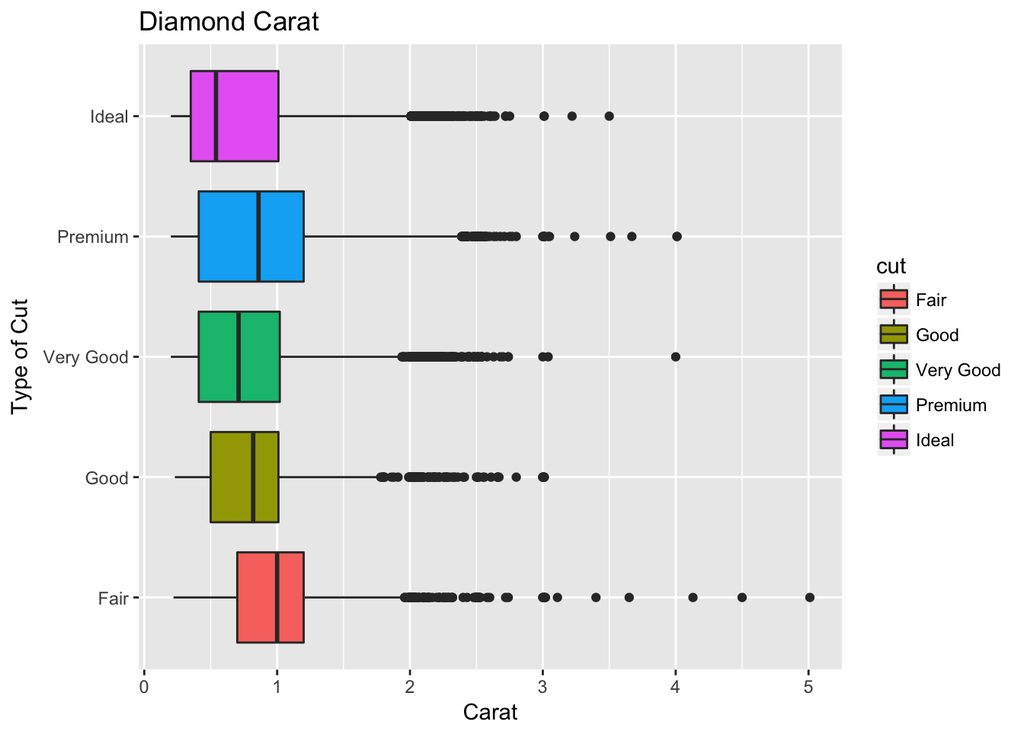

```r
ggplot(diamonds, aes(factor(cut), carat, fill=cut)) + geom_boxplot() + ggtitle("Diamond Carat") + xlab("Type of Cut") + ylab("Carat") + coord_flip()
```

### Data munging and wrangling (6 points)

Is this data “tidy”? If yes, leave it alone and go to the next problem. If no, make it tidy. Note: this data set is called table2 and is available in the tidyverse package. It should be ready for you to use after you’ve loaded the tidyverse package.

Answer: It is not tydy.

```r
library(tidyverse)

table2 %>%
    spread(key = type, value = count)
```

```
## # A tibble: 6 x 4
##   country      year  cases population
##   <chr>       <int>  <int>      <int>
## 1 Afghanistan  1999    745   19987071
## 2 Afghanistan  2000   2666   20595360
## 3 Brazil       1999  37737  172006362
## 4 Brazil       2000  80488  174504898
## 5 China        1999 212258 1272915272
## 6 China        2000 213766 1280428583
```

2)Create a new column in the diamonds data set called price_per_carat that shows the price of each diamond per carat (hint: divide). Only show me the code, not the output.

```r
new_diamonds <- mutate(diamonds, price_per_carat= price/carat )
new_diamonds
```

```
## # A tibble: 53,940 x 11
##    carat cut       color clarity depth table price     x     y     z
##    <dbl> <ord>     <ord> <ord>   <dbl> <dbl> <int> <dbl> <dbl> <dbl>
##  1 0.23  Ideal     E     SI2      61.5    55   326  3.95  3.98  2.43
##  2 0.21  Premium   E     SI1      59.8    61   326  3.89  3.84  2.31
##  3 0.23  Good      E     VS1      56.9    65   327  4.05  4.07  2.31
##  4 0.290 Premium   I     VS2      62.4    58   334  4.2   4.23  2.63
##  5 0.31  Good      J     SI2      63.3    58   335  4.34  4.35  2.75
##  6 0.24  Very Good J     VVS2     62.8    57   336  3.94  3.96  2.48
##  7 0.24  Very Good I     VVS1     62.3    57   336  3.95  3.98  2.47
##  8 0.26  Very Good H     SI1      61.9    55   337  4.07  4.11  2.53
##  9 0.22  Fair      E     VS2      65.1    61   337  3.87  3.78  2.49
## 10 0.23  Very Good H     VS1      59.4    61   338  4     4.05  2.39
## # ... with 53,930 more rows, and 1 more variable: price_per_carat <dbl>
```

3. For each cut of diamond in the diamonds data set, how many diamonds, and what proportion, have a price > 10000 and a carat < 1.5? There are several ways to get to an answer, but your solution must use the data wrangling verbs from the tidyverse in order to get credit. Do the results make sense? Why? Do we need to be wary of any of these numbers? Why?

```r
result <- diamonds %>%
  group_by(cut) %>%
  summarise(
  count = n() ,
  countpricemore1000= sum(price > 1000),
  countcaratless1.5 = sum (carat < 1.5))

result
```

```
## # A tibble: 5 x 4
##   cut       count countpricemore1000 countcaratless1.5
##   <ord>     <int>              <int>             <int>
## 1 Fair       1610               1499              1285
## 2 Good       4906               3794              4265
## 3 Very Good 12082               8836             10708
## 4 Premium   13791              10587             11552
## 5 Ideal     21551              14700             19895
```

## EDA (6 points)

Take a look at the txhousing data set that is included with the ggplot2 package and answer these questions:

```r
library(ggplot2)
```

#### How many cities are represented?

46 cities

```r
cities <- select(txhousing,city)
uniquecities <- count(unique(cities))
uniquecities
```

```
## # A tibble: 1 x 1
##       n
##   <int>
## 1    46
```

```r
txhousing %>%
  group_by(city,year,month) %>%
  summarise(
    maxsales= max(sales)
  )
```

```
## # A tibble: 8,602 x 4
## # Groups:   city, year [?]
##    city     year month maxsales
##    <chr>   <int> <int>    <dbl>
##  1 Abilene  2000     1       72
##  2 Abilene  2000     2       98
##  3 Abilene  2000     3      130
##  4 Abilene  2000     4       98
##  5 Abilene  2000     5      141
##  6 Abilene  2000     6      156
##  7 Abilene  2000     7      152
##  8 Abilene  2000     8      131
##  9 Abilene  2000     9      104
## 10 Abilene  2000    10      101
## # ... with 8,592 more rows
```

#### What kind of relationship do you think exists between the number of listings and the number of sales? Check your assumption and show your work.

The more listings, more houses are on the market which implies more sales.

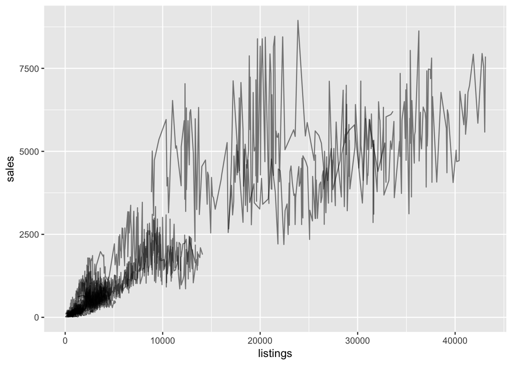

```r
ggplot(txhousing, aes(listings, sales)) +
  geom_line(aes(group = city), alpha = 1/2)
```

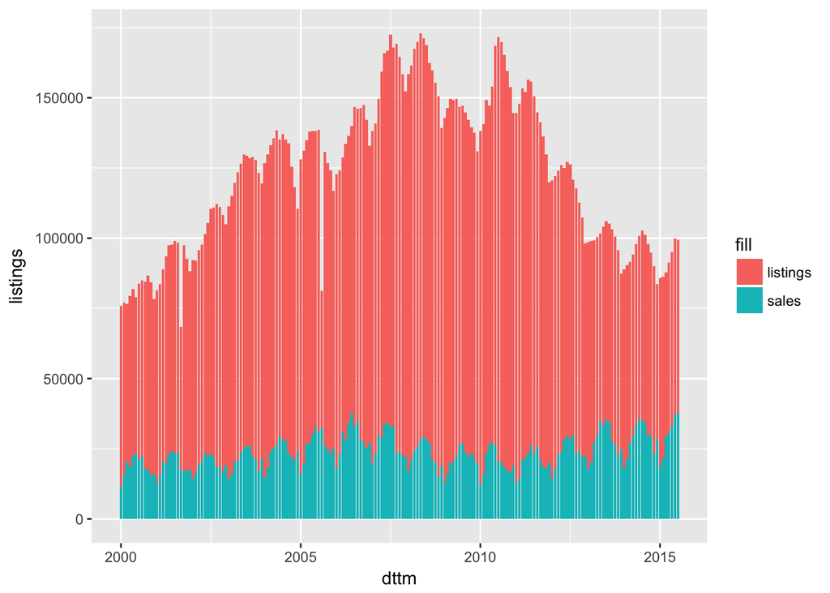

```r
library(ggplot2)
library(lubridate)
txhm <- add_column(txhousing, dttm = date_decimal(txhousing$date, tz = "UTC"))

normal.plot <- txhm %>%
  ggplot(aes(x=dttm)) +
  geom_col(aes(y = listings, fill = "listings")) +
  geom_col(aes(y = sales, fill = "sales"))
normal.plot
```

#### What proportion of sales is missing for each city?

```r
txhousing %>%
  group_by(city) %>%
summarise(missingsales=sum(is.na(sales)))
```

```
## # A tibble: 46 x 2
##    city                  missingsales
##    <chr>                        <int>
##  1 Abilene                          0
##  2 Amarillo                         0
##  3 Arlington                        0
##  4 Austin                           0
##  5 Bay Area                         0
##  6 Beaumont                         0
##  7 Brazoria County                 14
##  8 Brownsville                      2
##  9 Bryan-College Station            0
## 10 Collin County                    0
## # ... with 36 more rows
```

#### Looking at only the cities and months with greater than 500 sales:

```r
txhousing %>%
  group_by(city) %>%
  summarise(sales = sum(sales)) %>%
  filter(sales > 500)
```

```
## # A tibble: 26 x 2
##    city                   sales
##    <chr>                  <dbl>
##  1 Abilene                28141
##  2 Amarillo               44628
##  3 Arlington              79285
##  4 Austin                373381
##  5 Bay Area               93989
##  6 Beaumont               33110
##  7 Bryan-College Station  34921
##  8 Collin County         202892
##  9 Dallas                816122
## 10 Denton County         117405
## # ... with 16 more rows
```

#### Are the distributions of the median sales price (column name median), when grouped by city, different? The same? Show your work.

```r
txhousing %>%
  group_by(city) %>%
  summarise(
    sales = sum(sales),
    median = median(sales)) %>%
  filter(sales > 500)
```

```
## # A tibble: 26 x 3
##    city                   sales median
##    <chr>                  <dbl>  <dbl>
##  1 Abilene                28141  28141
##  2 Amarillo               44628  44628
##  3 Arlington              79285  79285
##  4 Austin                373381 373381
##  5 Bay Area               93989  93989
##  6 Beaumont               33110  33110
##  7 Bryan-College Station  34921  34921
##  8 Collin County         202892 202892
##  9 Dallas                816122 816122
## 10 Denton County         117405 117405
## # ... with 16 more rows
```

#### Any cities that stand out that you’d want to investigate further?

I would like to investigate the biggest city, Houston, averages over ~4000 sales per month and the smallest city, San Marcos which averages ~20 sales per month.

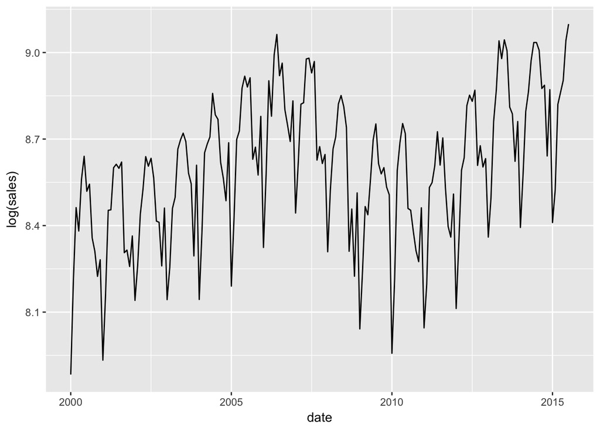

```r
abilene <- txhousing %>% filter(city == "Houston")
ggplot(abilene, aes(date, log(sales))) +
  geom_line()
```

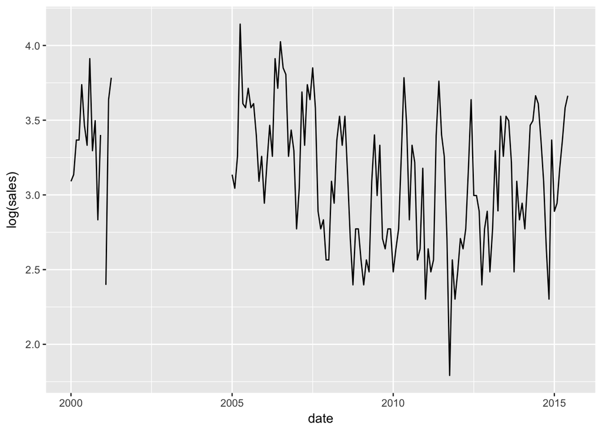

```r
abilene <- txhousing %>% filter(city == "San Marcos")
ggplot(abilene, aes(date, log(sales))) +
  geom_line()
```

#### Why might we want to filter out all cities and months with sales less than 500?

We might want to filter out all cities and months with sales less than 500 to be able to perform a better analysis